# RNA-Seq Workflow Template

Last update: 20 April, 2022

#### Package

systemPipeR 2.1.26

Source code downloads: [ .Rmd ]

## 0.1 Introduction

This report describes the analysis of the RNA-Seq data set from Howard et al (2013). The corresponding FASTQ files were downloaded from GEO (Accession: SRP010938). This data set contains 18 paired-end (PE) read sets from *Arabidposis thaliana*. The details about all download steps are provided [here](https://girke.bioinformatics.ucr.edu/GEN242/assignments/projects/project_data/).

### 0.1.2 Workflow environment

NOTE: this section describes how to set up the proper environment (directory structure) for running `systemPipeR` workflows. After mastering this task the workflow run instructions can be deleted since they are not expected to be included in a final HTML/PDF report of a workflow.

1. If a remote system or cluster is used, then users need to log in to the remote system first. The following applies to an HPC cluster (*e.g.* HPCC cluster).

   A terminal application needs to be used to log in to a user’s cluster account. Next, one can open an interactive session on a computer node with `srun`. More details about argument settings for `srun` are available in this [HPCC manual](http://hpcc.ucr.edu/manuals_linux-cluster_jobs.html#partitions) or the HPCC section of this website [here](https://girke.bioinformatics.ucr.edu/GEN242/tutorials/linux/linux/#job-submission-with-sbatch). Next, load the R version required for running the workflow with `module load`. Sometimes it may be necessary to first unload an active software version before loading another version, *e.g.* `module unload R`.

```bash
srun --x11 --partition=gen242 --mem=20gb --cpus-per-task 8 --ntasks 1 --time 20:00:00 --pty bash -l
module unload R; module load load R/4.1.2
```

2. Load a workflow template with the `genWorkenvir` function. This can be done from the command-line or from within R. However, only one of the two options needs to be used.

From command-line

```bash
$ Rscript -e "systemPipeRdata::genWorkenvir(workflow='rnaseq')"
$ cd rnaseq
```

From R

```r
library(systemPipeRdata)
genWorkenvir(workflow = "rnaseq")
setwd("rnaseq")
```

3. Optional: if the user wishes to use another `Rmd` file than the template instance provided by the `genWorkenvir` function, then it can be copied or downloaded into the root directory of the workflow environment (*e.g.* with `cp` or `wget`).
4. Now one can open from the root directory of the workflow the corresponding R Markdown script (*e.g.* systemPipeChIPseq.Rmd) using an R IDE, such as *nvim-r*, *ESS* or RStudio. Subsequently, the workflow can be run as outlined below. For learning purposes it is recommended to run workflows for the first time interactively. Once all workflow steps are understood and possibly modified to custom needs, one can run the workflow from start to finish with a single command using `runWF()`.

### 0.1.3 Load packages

The `systemPipeR` package needs to be loaded to perform the analysis steps shown in this report (H Backman and Girke 2016). The package allows users to run the entire analysis workflow interactively or with a single command while also generating the corresponding analysis report. For details see `systemPipeR's` main [vignette](http://www.bioconductor.org/packages/devel/bioc/vignettes/systemPipeR/inst/doc/systemPipeR.html).

```r
library(systemPipeR)
```

To apply workflows to custom data, the user needs to modify the *`targets`* file and if necessary update the corresponding parameter (*`.cwl`* and *`.yml`*) files. A collection of pre-generated *`.cwl`* and *`.yml`* files are provided in the *`param/cwl`* subdirectory of each workflow template. They are also viewable in the GitHub repository of *`systemPipeRdata`* ([see here](https://github.com/tgirke/systemPipeRdata/tree/master/inst/extdata/param/cwl)). For more information of the structure of the *targets* file, please consult the documentation [here](http://www.bioconductor.org/packages/devel/bioc/vignettes/systemPipeR/inst/doc/systemPipeR.html#25_structure_of_targets_file). More details about the new parameter files from systemPipeR can be found [here](http://www.bioconductor.org/packages/devel/bioc/vignettes/systemPipeR/inst/doc/systemPipeR.html#26_structure_of_the_new_param_files_and_construct_sysargs2_container).

### 0.1.4 Import custom functions

Custom functions for the challenge projects can be imported with the source command from a local R script (here challengeProject_Fct.R). Skip this step if such a script is not available. Alternatively, these functions can be loaded from a custom R package.

```r
source("challengeProject_Fct.R")
```

### 0.1.5 Experiment definition provided by `targets` file

The `targets` file defines all FASTQ files and sample comparisons of the analysis workflow. If needed the tab separated (TSV) version of this file can be downloaded from [here](https://github.com/tgirke/GEN242/tree/main/content/en/assignments/Projects/targets_files) and the corresponding Google Sheet is [here](https://docs.google.com/spreadsheets/d/1DTgTGlZZscSPjlHOGdJC8QK4vvimN1BORjXKXzd_cfA/edit#gid=472150521).

```r
targetspath <- "targetsPE.txt"
targets <- read.delim(targetspath, comment.char = "#")
DT::datatable(targets, options = list(scrollX = TRUE, autoWidth = TRUE))
```

|  | FileName1 | FileName2 | SampleName | Factor | SampleLong | Experiment | Date |
| --- | --- | --- | --- | --- | --- | --- | --- |
| 1 | ./data/SRR446027_1.fastq.gz | ./data/SRR446027_2.fastq.gz | M1A | M1 | Mock.1h.A | 1 | 23-Mar-2012 |
| 2 | ./data/SRR446028_1.fastq.gz | ./data/SRR446028_2.fastq.gz | M1B | M1 | Mock.1h.B | 1 | 23-Mar-2012 |
| 3 | ./data/SRR446029_1.fastq.gz | ./data/SRR446029_2.fastq.gz | A1A | A1 | Avr.1h.A | 1 | 23-Mar-2012 |
| 4 | ./data/SRR446030_1.fastq.gz | ./data/SRR446030_2.fastq.gz | A1B | A1 | Avr.1h.B | 1 | 23-Mar-2012 |
| 5 | ./data/SRR446031_1.fastq.gz | ./data/SRR446031_2.fastq.gz | V1A | V1 | Vir.1h.A | 1 | 23-Mar-2012 |
| 6 | ./data/SRR446032_1.fastq.gz | ./data/SRR446032_2.fastq.gz | V1B | V1 | Vir.1h.B | 1 | 23-Mar-2012 |
| 7 | ./data/SRR446033_1.fastq.gz | ./data/SRR446033_2.fastq.gz | M6A | M6 | Mock.6h.A | 1 | 23-Mar-2012 |
| 8 | ./data/SRR446034_1.fastq.gz | ./data/SRR446034_2.fastq.gz | M6B | M6 | Mock.6h.B | 1 | 23-Mar-2012 |
| 9 | ./data/SRR446035_1.fastq.gz | ./data/SRR446035_2.fastq.gz | A6A | A6 | Avr.6h.A | 1 | 23-Mar-2012 |
| 10 | ./data/SRR446036_1.fastq.gz | ./data/SRR446036_2.fastq.gz | A6B | A6 | Avr.6h.B | 1 | 23-Mar-2012 |

[output cut: 8 more lines]

## 0.2 Workflow steps

This tutorial will demonstrate how to build the workflow in an interactive mode, appending each step. The workflow is constructed by connecting each step via `appendStep` method. Each `SYSargsList` instance contains instructions for processing a set of input files with a specific command-line or R software and the paths to the corresponding outfiles generated by a particular command-line software/step.

To create a workflow within *`systemPipeR`*, we can start by defining an empty container and checking the directory structure:

```r
library(systemPipeR)
sal <- SPRproject()
sal
```

### 0.2.1 Required packages and resources

The `systemPipeR` package needs to be loaded (H Backman and Girke 2016).

```r
appendStep(sal) <- LineWise(code = {
    library(systemPipeR)
}, step_name = "load_SPR")
```

### 0.2.2 Read preprocessing

#### 0.2.2.1 Read quality filtering and trimming

The function `preprocessReads` allows to apply predefined or custom read preprocessing functions to all FASTQ files referenced in a `SYSargsList` container, such as quality filtering or adapter trimming routines. The paths to the resulting output FASTQ files are stored in the `outfiles` slot of the `SYSargsList` object. The following example performs adapter trimming with the `trimLRPatterns` function from the `Biostrings` package. After the trimming step a new targets file is generated (here `targets_trim.txt`) containing the paths to the trimmed FASTQ files. The new targets file can be used for the next workflow step with an updated `SYSargs2` instance, *e.g.* running the NGS alignments using the trimmed FASTQ files.

Here, we are appending this step to the `SYSargsList` object created previously. All the parameters are defined on the `preprocessReads/preprocessReads-pe.yml` and `preprocessReads/preprocessReads-pe.cwl` files.

```r
appendStep(sal) <- SYSargsList(step_name = "preprocessing", targets = "targetsPE.txt",
    dir = TRUE, wf_file = "preprocessReads/preprocessReads-pe.cwl",
    input_file = "preprocessReads/preprocessReads-pe.yml", dir_path = "param/cwl",
    inputvars = c(FileName1 = "_FASTQ_PATH1_", FileName2 = "_FASTQ_PATH2_",
        SampleName = "_SampleName_"), dependency = c("load_SPR"))
```

After, we can check the `trimLRPatterns` function in input parameter:

```r
yamlinput(sal, "preprocessing")$Fct
```

After the preprocessing step, the `outfiles` files can be used to generate the new targets files containing the paths to the trimmed FASTQ files. The new targets information can be used for the next workflow step instance, *e.g.* running the NGS alignments with the trimmed FASTQ files. The `appendStep` function is automatically handling this connectivity between steps. Please check the `Alignments` step for more details.

#### 0.2.2.2 FASTQ quality report

The following `seeFastq` and `seeFastqPlot` functions generate and plot a series of useful quality statistics for a set of FASTQ files including per cycle quality box plots, base proportions, base-level quality trends, relative k-mer diversity, length and occurrence distribution of reads, number of reads above quality cutoffs and mean quality distribution. The results are written to a PDF file named `fastqReport.pdf`.

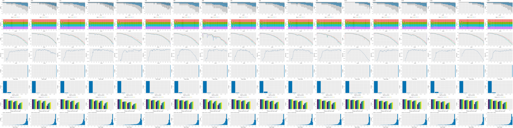

```r
appendStep(sal) <- LineWise(code = {
    fastq <- getColumn(sal, step = "preprocessing", "targetsWF",
        column = 1)
    fqlist <- seeFastq(fastq = fastq, batchsize = 10000, klength = 8)
    pdf("./results/fastqReport.pdf", height = 18, width = 4 *
        length(fqlist))
    seeFastqPlot(fqlist)
    dev.off()
}, step_name = "fastq_report", dependency = "preprocessing")
```

Figure 1: FASTQ quality report for 18 samples

### 0.2.3 Alignments

#### 0.2.3.1 Read mapping with `HISAT2`

The following steps will demonstrate how to use the short read aligner `Hisat2` (Kim, Langmead, and Salzberg 2015) in both interactive job submissions and batch submissions to queuing systems of clusters using the *`systemPipeR's`* new CWL command-line interface.

The following steps will demonstrate how to use the short read aligner `Hisat2` (Kim, Langmead, and Salzberg 2015). First, the `Hisat2` index needs to be created.

```r
appendStep(sal) <- SYSargsList(step_name = "hisat2_index", dir = FALSE,
    targets = NULL, wf_file = "hisat2/hisat2-index.cwl", input_file = "hisat2/hisat2-index.yml",
    dir_path = "param/cwl", dependency = "load_SPR")
```

The parameter settings of the aligner are defined in the `workflow_hisat2-pe.cwl` and `workflow_hisat2-pe.yml` files. The following shows how to construct the corresponding *SYSargsList* object. Please note that the targets used in this step are the outfiles from `preprocessing` step.

```r
appendStep(sal) <- SYSargsList(step_name = "hisat2_mapping",
    dir = TRUE, targets = "preprocessing", wf_file = "workflow-hisat2/workflow_hisat2-pe.cwl",
    input_file = "workflow-hisat2/workflow_hisat2-pe.yml", dir_path = "param/cwl",
    inputvars = c(preprocessReads_1 = "_FASTQ_PATH1_", preprocessReads_2 = "_FASTQ_PATH2_",
        SampleName = "_SampleName_"), rm_targets_col = c("FileName1",
        "FileName2"), dependency = c("preprocessing", "hisat2_index"))
```

To double-check the command line for each sample, please use the following:

```r
cmdlist(sal, step = "hisat2_mapping", targets = 1)
```

#### 0.2.3.2 Read and alignment stats

The following provides an overview of the number of reads in each sample and how many of them aligned to the reference.

```r
appendStep(sal) <- LineWise(code = {
    fqpaths <- getColumn(sal, step = "preprocessing", "targetsWF",
        column = "FileName1")
    bampaths <- getColumn(sal, step = "hisat2_mapping", "outfiles",
        column = "samtools_sort_bam")
    read_statsDF <- alignStats(args = bampaths, fqpaths = fqpaths,
        pairEnd = TRUE)
    write.table(read_statsDF, "results/alignStats.xls", row.names = FALSE,
        quote = FALSE, sep = "\t")
}, step_name = "align_stats", dependency = "hisat2_mapping")
```

The following shows the alignment statistics for a sample file provided by the `systemPipeR` package.

```r
read.table("results/alignStats.xls", header = TRUE)[1:4, ]
```

```
##   FileName Nreads2x   Nalign Perc_Aligned Nalign_Primary
## 1      M1A 33609678 32136300     95.61621       32136300
## 2      M1B 53002402 43620124     82.29839       43620124
## 3      A1A 50223496 48438407     96.44571       48438407
## 4      A1B 43650000 35549889     81.44304       35549889
##   Perc_Aligned_Primary
## 1             95.61621
## 2             82.29839
## 3             96.44571
## 4             81.44304
```

#### 0.2.3.3 Create symbolic links for viewing BAM files in IGV

The `symLink2bam` function creates symbolic links to view the BAM alignment files in a genome browser such as IGV without moving these large files to a local system. The corresponding URLs are written to a file with a path specified under `urlfile`, here `IGVurl.txt`. Please replace the directory and the user name.

```r
appendStep(sal) <- LineWise(code = {
    bampaths <- getColumn(sal, step = "hisat2_mapping", "outfiles",
        column = "samtools_sort_bam")
    symLink2bam(sysargs = bampaths, htmldir = c("~/.html/", "somedir/"),
        urlbase = "http://cluster.hpcc.ucr.edu/~<username>/",
        urlfile = "./results/IGVurl.txt")
}, step_name = "bam_urls", dependency = "hisat2_mapping", run_step = "optional")
```

### 0.2.4 Read quantification

Reads overlapping with annotation ranges of interest are counted for each sample using the `summarizeOverlaps` function (Lawrence et al. 2013). The read counting is preformed for exonic gene regions in a non-strand-specific manner while ignoring overlaps among different genes. Subsequently, the expression count values are normalized by *reads per kp per million mapped reads* (RPKM). The raw read count table (`countDFeByg.xls`) and the corresponding RPKM table (`rpkmDFeByg.xls`) are written to separate files in the directory of this project. Parallelization is achieved with the `BiocParallel` package, here using 4 CPU cores.

#### 0.2.4.1 Create a database for gene annotation

```r
appendStep(sal) <- LineWise(code = {
    library(GenomicFeatures)
    txdb <- suppressWarnings(makeTxDbFromGFF(file = "data/tair10.gff",
        format = "gff", dataSource = "TAIR", organism = "Arabidopsis thaliana"))
    saveDb(txdb, file = "./data/tair10.sqlite")
}, step_name = "create_db", dependency = "hisat2_mapping")
```

#### 0.2.4.2 Read counting with `summarizeOverlaps` in parallel mode using multiple cores

```r
appendStep(sal) <- LineWise(code = {
    library(GenomicFeatures)
    library(BiocParallel)
    txdb <- loadDb("./data/tair10.sqlite")
    outpaths <- getColumn(sal, step = "hisat2_mapping", "outfiles",
        column = "samtools_sort_bam")
    eByg <- exonsBy(txdb, by = c("gene"))
    bfl <- BamFileList(outpaths, yieldSize = 50000, index = character())
    multicoreParam <- MulticoreParam(workers = 4)
    register(multicoreParam)
    registered()
    counteByg <- bplapply(bfl, function(x) summarizeOverlaps(eByg,
        x, mode = "Union", ignore.strand = TRUE, inter.feature = FALSE,
        singleEnd = FALSE, BPPARAM = multicoreParam))
    countDFeByg <- sapply(seq(along = counteByg), function(x) assays(counteByg[[x]])$counts)
    rownames(countDFeByg) <- names(rowRanges(counteByg[[1]]))
    colnames(countDFeByg) <- names(bfl)
    rpkmDFeByg <- apply(countDFeByg, 2, function(x) returnRPKM(counts = x,
        ranges = eByg))
    write.table(countDFeByg, "results/countDFeByg.xls", col.names = NA,
        quote = FALSE, sep = "\t")
    write.table(rpkmDFeByg, "results/rpkmDFeByg.xls", col.names = NA,
        quote = FALSE, sep = "\t")
    ## Creating a SummarizedExperiment object
    colData <- data.frame(row.names = SampleName(sal, "hisat2_mapping"),
        condition = getColumn(sal, "hisat2_mapping", position = "targetsWF",
            column = "Factor"))
    colData$condition <- factor(colData$condition)
    countDF_se <- SummarizedExperiment::SummarizedExperiment(assays = countDFeByg,
        colData = colData)
    ## Add results as SummarizedExperiment to the workflow
    ## object
    SE(sal, "read_counting") <- countDF_se
}, step_name = "read_counting", dependency = "create_db")
```

When providing a `BamFileList` as in the example above, `summarizeOverlaps` methods use by default `bplapply` and use the register interface from BiocParallel package. If the number of workers is not set, `MulticoreParam` will use the number of cores returned by `parallel::detectCores()`. For more information, please check `help("summarizeOverlaps")` documentation.

Shows count table generated in previous step (`countDFeByg.xls`). To avoid slowdowns of the load time of this page, ony 200 rows of the source table are imported into the below `datatable` view .

```r
countDF <- read.delim("results/countDFeByg.xls", row.names = 1,
    check.names = FALSE)[1:200, ]
DT::datatable(countDF, options = list(scrollX = TRUE, autoWidth = TRUE))
```

|  | M1A | M1B | A1A | A1B | V1A | V1B | M6A | M6B | A6A | A6B | V6A | V6B | M12A | M12B | A12A | A12B | V12A | V12B |
| --- | --- | --- | --- | --- | --- | --- | --- | --- | --- | --- | --- | --- | --- | --- | --- | --- | --- | --- |
| AT1G01010 | 405 | 577 | 625 | 329 | 903 | 517 | 597 | 339 | 1185 | 861 | 2141 | 1370 | 310 | 562 | 1269 | 1424 | 1017 | 1571 |
| AT1G01020 | 155 | 327 | 235 | 243 | 282 | 269 | 349 | 294 | 294 | 297 | 529 | 575 | 104 | 359 | 326 | 372 | 143 | 366 |
| AT1G01030 | 185 | 202 | 281 | 100 | 225 | 329 | 169 | 69 | 63 | 190 | 290 | 519 | 79 | 136 | 91 | 164 | 280 | 1006 |
| AT1G01040 | 1342 | 1732 | 1737 | 1200 | 1605 | 1580 | 2032 | 1399 | 2038 | 1764 | 4308 | 3800 | 983 | 2724 | 3359 | 2245 | 1076 | 2326 |
| AT1G01046 | 30 | 29 | 30 | 17 | 28 | 41 | 49 | 26 | 63 | 40 | 71 | 93 | 37 | 43 | 86 | 40 | 37 | 54 |
| AT1G01050 | 283 | 367 | 435 | 306 | 356 | 663 | 1210 | 1398 | 909 | 1150 | 1674 | 2401 | 1013 | 3321 | 1836 | 1732 | 997 | 2296 |
| AT1G01060 | 139 | 698 | 145 | 148 | 52 | 49 | 12 | 10 | 10 | 4 | 3 | 14 | 321 | 770 | 1207 | 651 | 254 | 386 |
| AT1G01070 | 5 | 2 | 7 | 1 | 16 | 6 | 26 | 31 | 64 | 24 | 71 | 47 | 14 | 125 | 161 | 141 | 35 | 46 |
| AT1G01073 | 0 | 0 | 0 | 0 | 0 | 0 | 0 | 0 | 0 | 0 | 0 | 0 | 0 | 0 | 0 | 0 | 0 | 0 |
| AT1G01080 | 546 | 1025 | 630 | 882 | 759 | 1128 | 1091 | 1716 | 602 | 924 | 971 | 1841 | 639 | 2603 | 887 | 984 | 406 | 940 |

[output cut: 190 more lines]

A data slice of RPKM table (`rpkmDFeByg.xls`) is shown here.

```r
read.delim("results/rpkmDFeByg.xls", row.names = 1, check.names = FALSE)[1:4,
    1:4]
```

```
##                 M1A       M1B       A1A       A1B
## AT1G01010 15.552350 15.855557 15.515099 11.482534
## AT1G01020  5.663586  8.550121  5.550872  8.069877
## AT1G01030  6.294920  4.918521  6.180994  3.092568
## AT1G01040 13.909390 12.846007 11.638283 11.304143
```

Note, for most statistical differential expression or abundance analysis methods, such as `edgeR` or `DESeq2`, the raw count values should be used as input. The usage of RPKM values should be restricted to specialty applications required by some users, *e.g.* manually comparing the expression levels among different genes or features.

#### 0.2.4.3 Sample-wise correlation analysis

The following computes the sample-wise Spearman correlation coefficients from the `rlog` transformed expression values generated with the `DESeq2` package. After transformation to a distance matrix, hierarchical clustering is performed with the `hclust` function and the result is plotted as a dendrogram (also see file `sample_tree.pdf`).

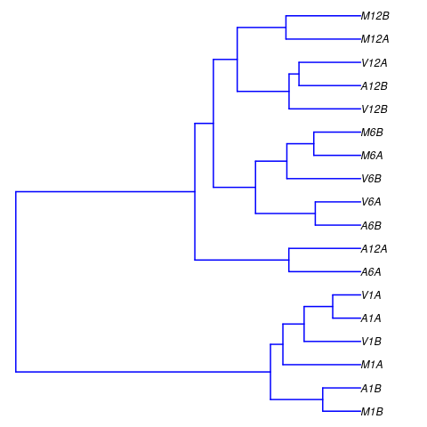

```r
appendStep(sal) <- LineWise(code = {
    library(DESeq2, quietly = TRUE)
    library(ape, warn.conflicts = FALSE)
    ## Extracting SummarizedExperiment object
    se <- SE(sal, "read_counting")
    dds <- DESeqDataSet(se, design = ~condition)
    d <- cor(assay(rlog(dds)), method = "spearman")
    hc <- hclust(dist(1 - d))
    pdf("results/sample_tree.pdf")
    plot.phylo(as.phylo(hc), type = "p", edge.col = "blue", edge.width = 2,
        show.node.label = TRUE, no.margin = TRUE)
    dev.off()
}, step_name = "sample_tree", dependency = "read_counting")
```

Figure 2: Correlation dendrogram of samples

### 0.2.5 Analysis of DEGs

The analysis of differentially expressed genes (DEGs) is performed with the glm method of the `edgeR` package (Robinson, McCarthy, and Smyth 2010). The sample comparisons used by this analysis are defined in the header lines of the `targets.txt` file starting with `<CMP>`.

#### 0.2.5.1 Run `edgeR`

```r
appendStep(sal) <- LineWise(code = {
    library(edgeR)
    countDF <- read.delim("results/countDFeByg.xls", row.names = 1,
        check.names = FALSE)
    cmp <- readComp(stepsWF(sal)[["hisat2_mapping"]], format = "matrix",
        delim = "-")
    edgeDF <- run_edgeR(countDF = countDF, targets = targetsWF(sal)[["hisat2_mapping"]],
        cmp = cmp[[1]], independent = FALSE, mdsplot = "")
}, step_name = "run_edger", dependency = "read_counting")
```

#### 0.2.5.2 Add gene descriptions

```r
appendStep(sal) <- LineWise(code = {
    library("biomaRt")
    m <- useMart("plants_mart", dataset = "athaliana_eg_gene",
        host = "https://plants.ensembl.org")
    desc <- getBM(attributes = c("tair_locus", "description"),
        mart = m)
    desc <- desc[!duplicated(desc[, 1]), ]
    descv <- as.character(desc[, 2])
    names(descv) <- as.character(desc[, 1])
    edgeDF <- data.frame(edgeDF, Desc = descv[rownames(edgeDF)],
        check.names = FALSE)
    write.table(edgeDF, "./results/edgeRglm_allcomp.xls", quote = FALSE,
        sep = "\t", col.names = NA)
}, step_name = "custom_annot", dependency = "run_edger")
```

### 0.2.6 Plot DEG results

Filter and plot DEG results for up and down regulated genes. The definition of *up* and *down* is given in the corresponding help file. To open it, type `?filterDEGs` in the R console.

```r
appendStep(sal) <- LineWise(code = {
    edgeDF <- read.delim("results/edgeRglm_allcomp.xls", row.names = 1,
        check.names = FALSE)
    pdf("results/DEGcounts.pdf")
    DEG_list <- filterDEGs(degDF = edgeDF, filter = c(Fold = 2,
        FDR = 20))
    dev.off()
    write.table(DEG_list$Summary, "./results/DEGcounts.xls",
        quote = FALSE, sep = "\t", row.names = FALSE)
}, step_name = "filter_degs", dependency = "custom_annot")
```

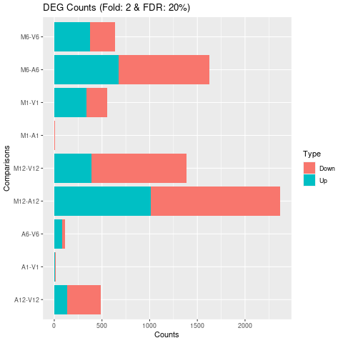

### 0.2.7 Venn diagrams of DEG sets

The `overLapper` function can compute Venn intersects for large numbers of sample sets (up to 20 or more) and plots 2-5 way Venn diagrams. A useful feature is the possibility to combine the counts from several Venn comparisons with the same number of sample sets in a single Venn diagram (here for 4 up and down DEG sets).

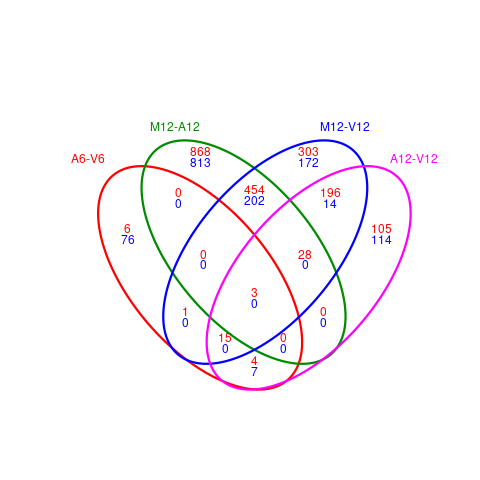

```r
appendStep(sal) <- LineWise(code = {
    vennsetup <- overLapper(DEG_list$Up[6:9], type = "vennsets")
    vennsetdown <- overLapper(DEG_list$Down[6:9], type = "vennsets")
    pdf("results/vennplot.pdf")
    vennPlot(list(vennsetup, vennsetdown), mymain = "", mysub = "",
        colmode = 2, ccol = c("blue", "red"))
    dev.off()
}, step_name = "venn_diagram", dependency = "filter_degs")
```

Figure 4: Venn Diagram for 4 Up and Down DEG Sets

### 0.2.8 GO term enrichment analysis

#### 0.2.8.1 Obtain gene-to-GO mappings

The following shows how to obtain gene-to-GO mappings from `biomaRt` (here for *A. thaliana*) and how to organize them for the downstream GO term enrichment analysis. Alternatively, the gene-to-GO mappings can be obtained for many organisms from Bioconductor’s `*.db` genome annotation packages or GO annotation files provided by various genome databases. For each annotation this relatively slow preprocessing step needs to be performed only once. Subsequently, the preprocessed data can be loaded with the `load` function as shown in the next subsection.

```r
appendStep(sal) <- LineWise(code = {
    library("biomaRt")
    # listMarts() # To choose BioMart database
    # listMarts(host='plants.ensembl.org')
    m <- useMart("plants_mart", host = "https://plants.ensembl.org")
    m <- useMart("plants_mart", dataset = "athaliana_eg_gene",
        host = "https://plants.ensembl.org")
    go <- getBM(attributes = c("go_id", "tair_locus", "namespace_1003"),
        mart = m)
    go <- go[go[, 3] != "", ]
    go[, 3] <- as.character(go[, 3])
    go[go[, 3] == "molecular_function", 3] <- "F"
    go[go[, 3] == "biological_process", 3] <- "P"
    go[go[, 3] == "cellular_component", 3] <- "C"
    go[1:4, ]
    if (!dir.exists("./data/GO"))
        dir.create("./data/GO")
    write.table(go, "data/GO/GOannotationsBiomart_mod.txt", quote = FALSE,
        row.names = FALSE, col.names = FALSE, sep = "\t")
    catdb <- makeCATdb(myfile = "data/GO/GOannotationsBiomart_mod.txt",
        lib = NULL, org = "", colno = c(1, 2, 3), idconv = NULL)
    save(catdb, file = "data/GO/catdb.RData")
}, step_name = "get_go_annot", dependency = "filter_degs")
```

#### 0.2.8.2 Batch GO term enrichment analysis

Apply the enrichment analysis to the DEG sets obtained the above differential expression analysis. Note, in the following example the `FDR` filter is set here to an unreasonably high value, simply because of the small size of the toy data set used in this vignette. Batch enrichment analysis of many gene sets is performed with the function. When `method=all`, it returns all GO terms passing the p-value cutoff specified under the `cutoff` arguments. When `method=slim`, it returns only the GO terms specified under the `myslimv` argument. The given example shows how a GO slim vector for a specific organism can be obtained from `BioMart`.

```r
appendStep(sal) <- LineWise(code = {
    library("biomaRt")
    load("data/GO/catdb.RData")
    DEG_list <- filterDEGs(degDF = edgeDF, filter = c(Fold = 2,
        FDR = 50), plot = FALSE)
    up_down <- DEG_list$UporDown
    names(up_down) <- paste(names(up_down), "_up_down", sep = "")
    up <- DEG_list$Up
    names(up) <- paste(names(up), "_up", sep = "")
    down <- DEG_list$Down
    names(down) <- paste(names(down), "_down", sep = "")
    DEGlist <- c(up_down, up, down)
    DEGlist <- DEGlist[sapply(DEGlist, length) > 0]
    BatchResult <- GOCluster_Report(catdb = catdb, setlist = DEGlist,
        method = "all", id_type = "gene", CLSZ = 2, cutoff = 0.9,
        gocats = c("MF", "BP", "CC"), recordSpecGO = NULL)
    m <- useMart("plants_mart", dataset = "athaliana_eg_gene",
        host = "https://plants.ensembl.org")
    goslimvec <- as.character(getBM(attributes = c("goslim_goa_accession"),
        mart = m)[, 1])
    BatchResultslim <- GOCluster_Report(catdb = catdb, setlist = DEGlist,
        method = "slim", id_type = "gene", myslimv = goslimvec,
        CLSZ = 10, cutoff = 0.01, gocats = c("MF", "BP", "CC"),
        recordSpecGO = NULL)
    write.table(BatchResultslim, "results/GOBatchSlim.xls", row.names = FALSE,
        quote = FALSE, sep = "\t")
}, step_name = "go_enrich", dependency = "get_go_annot")
```

Shows GO term enrichment results from previous step. The last gene identifier column (10) of this table has been excluded in this viewing instance to minimize the complexity of the result. To avoid slowdowns of the load time of this page, only 10 rows of the source table are shown below.

```r
BatchResult <- read.delim("results/GOBatchAll.xls")[1:10, ]
knitr::kable(BatchResult[, -10])
```

| CLID | CLSZ | GOID | NodeSize | SampleMatch | Phyper | Padj | Term | Ont |
| --- | --- | --- | --- | --- | --- | --- | --- | --- |
| M1-A1_up_down | 26 | GO:0050291 | 4 | 1 | 0.0039621 | 0.0396207 | sphingosine N-acyltransferase activity | MF |
| M1-A1_up_down | 26 | GO:0004345 | 6 | 1 | 0.0059375 | 0.0593750 | glucose-6-phosphate dehydrogenase activity | MF |
| M1-A1_up_down | 26 | GO:0050664 | 11 | 1 | 0.0108597 | 0.1085975 | oxidoreductase activity, acting on NAD(P)H, oxygen as acceptor | MF |
| M1-A1_up_down | 26 | GO:0052593 | 11 | 1 | 0.0108597 | 0.1085975 | tryptamine:oxygen oxidoreductase (deaminating) activity | MF |
| M1-A1_up_down | 26 | GO:0052594 | 11 | 1 | 0.0108597 | 0.1085975 | aminoacetone:oxygen oxidoreductase(deaminating) activity | MF |
| M1-A1_up_down | 26 | GO:0052595 | 11 | 1 | 0.0108597 | 0.1085975 | aliphatic-amine oxidase activity | MF |
| M1-A1_up_down | 26 | GO:0052596 | 11 | 1 | 0.0108597 | 0.1085975 | phenethylamine:oxygen oxidoreductase (deaminating) activity | MF |
| M1-A1_up_down | 26 | GO:0052793 | 12 | 1 | 0.0118414 | 0.1184141 | pectin acetylesterase activity | MF |
| M1-A1_up_down | 26 | GO:0008131 | 15 | 1 | 0.0147808 | 0.1478083 | primary amine oxidase activity | MF |
| M1-A1_up_down | 26 | GO:0016018 | 16 | 1 | 0.0157588 | 0.1575878 | cyclosporin A binding | MF |

#### 0.2.8.3 Plot batch GO term results

The `data.frame` generated by `GOCluster` can be plotted with the `goBarplot` function. Because of the variable size of the sample sets, it may not always be desirable to show the results from different DEG sets in the same bar plot. Plotting single sample sets is achieved by subsetting the input data frame as shown in the first line of the following example.

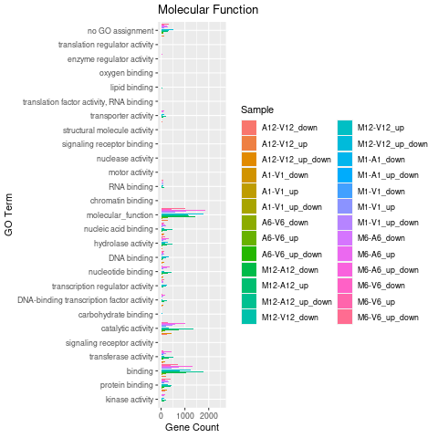

```r
appendStep(sal) <- LineWise(code = {
    gos <- BatchResultslim[grep("M6-V6_up_down", BatchResultslim$CLID),
        ]
    gos <- BatchResultslim
    png("results/GOslimbarplotMF.png")
    goBarplot(gos, gocat = "MF")
    dev.off()
    png("results/GOslimbarplotBP.png")
    goBarplot(gos, gocat = "BP")
    dev.off()
    png("results/GOslimbarplotCC.png")
    goBarplot(gos, gocat = "CC")
    dev.off()
}, step_name = "go_plot", dependency = "go_enrich")
```

Figure 5: GO Slim Barplot for MF Ontology

### 0.2.9 Clustering and heat maps

The following example performs hierarchical clustering on the `rlog` transformed expression matrix subsetted by the DEGs identified in the above differential expression analysis. It uses a Pearson correlation-based distance measure and complete linkage for cluster joining.

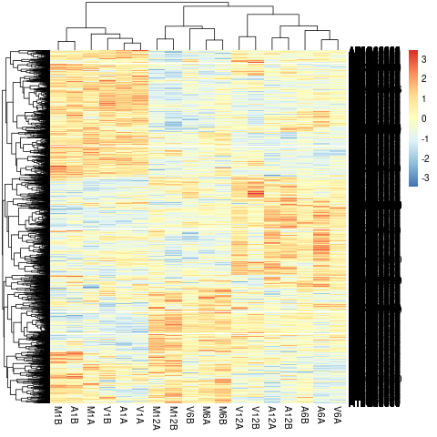

```r
appendStep(sal) <- LineWise(code = {
    library(pheatmap)
    geneids <- unique(as.character(unlist(DEG_list[[1]])))
    y <- assay(rlog(dds))[geneids, ]
    pdf("results/heatmap1.pdf")
    pheatmap(y, scale = "row", clustering_distance_rows = "correlation",
        clustering_distance_cols = "correlation")
    dev.off()
}, step_name = "heatmap", dependency = "go_enrich")
```

Figure 6: Heat Map with Hierarchical Clustering Dendrograms of DEGs

### 0.2.10 Version Information

```r
appendStep(sal) <- LineWise(code = {
    sessionInfo()
}, step_name = "sessionInfo", dependency = "heatmap")
```

## 0.3 Running workflow

### 0.3.1 Interactive job submissions in a single machine

For running the workflow, `runWF` function will execute all the steps store in the `SYSargsList` workflow container. The execution will be on a single machine without submitting to a queuing system of a computer cluster. Besides, `runWF` allows the user to create a dedicated results folder for each workflow. This includes all the output and log files for each step. When these options are used, the output location will be updated by default and can be assigned to the same object.

```r
sal <- runWF(sal)
```

### 0.3.2 Parallelization on clusters

Alternatively, the computation can be greatly accelerated by processing many files in parallel using several compute nodes of a cluster, where a scheduling/queuing system is used for load balancing.

The `resources` list object provides the number of independent parallel cluster processes defined under the `Njobs` element in the list. The following example will run 18 processes in parallel using each 4 CPU cores. If the resources available on a cluster allow running all 18 processes at the same time, then the shown sample submission will utilize in a total of 72 CPU cores.

Note, `runWF` can be used with most queueing systems as it is based on utilities from the `batchtools` package, which supports the use of template files (*`*.tmpl`*) for defining the run parameters of different schedulers. To run the following code, one needs to have both a `conffile` (see *`.batchtools.conf.R`* samples [here](https://mllg.github.io/batchtools/)) and a `template` file (see *`*.tmpl`* samples [here](https://github.com/mllg/batchtools/tree/master/inst/templates)) for the queueing available on a system. The following example uses the sample `conffile` and `template` files for the Slurm scheduler provided by this package.

The resources can be appended when the step is generated, or it is possible to add these resources later, as the following example using the `addResources` function:

```r
resources <- list(conffile=".batchtools.conf.R",
                  template="batchtools.slurm.tmpl",
                  Njobs=18,
                  walltime=120, ## minutes
                  ntasks=1,
                  ncpus=4,
                  memory=1024, ## Mb
                  partition = "short"
                  )
sal <- addResources(sal, step = c("hisat2_mapping"), resources = resources)
sal <- runWF(sal)
```

### 0.3.3 Visualize workflow

*`systemPipeR`* workflows instances can be visualized with the `plotWF` function.

```r
plotWF(sal, out_format = "html", out_path = "plotWF.html")
```

## 0.4 Checking workflow status

To check the summary of the workflow, we can use:

```r
sal
statusWF(sal)
```

## 0.5 Accessing logs report

*`systemPipeR`* compiles all the workflow execution logs in one central location, making it easier to check any standard output (`stdout`) or standard error (`stderr`) for any command-line tools used on the workflow or the R code stdout.

```r
sal <- renderLogs(sal)
```

## 0.6 Funding

This project was supported by funds from the National Institutes of Health (NIH).

## References

H Backman, Tyler W, and Thomas Girke. 2016. “systemPipeR: NGS workflow and report generation environment.” *BMC Bioinformatics* 17 (1): 388. https://doi.org/10.1186/s12859-016-1241-0.

Howard, Brian E, Qiwen Hu, Ahmet Can Babaoglu, Manan Chandra, Monica Borghi, Xiaoping Tan, Luyan He, et al. 2013. “High-Throughput RNA Sequencing of Pseudomonas-Infected Arabidopsis Reveals Hidden Transcriptome Complexity and Novel Splice Variants.” *PLoS One* 8 (10): e74183. https://doi.org/10.1371/journal.pone.0074183.

Kim, Daehwan, Ben Langmead, and Steven L Salzberg. 2015. “HISAT: A Fast Spliced Aligner with Low Memory Requirements.” *Nat. Methods* 12 (4): 357–60.

Lawrence, Michael, Wolfgang Huber, Hervé Pagès, Patrick Aboyoun, Marc Carlson, Robert Gentleman, Martin T Morgan, and Vincent J Carey. 2013. “Software for Computing and Annotating Genomic Ranges.” *PLoS Comput. Biol.* 9 (8): e1003118. https://doi.org/10.1371/journal.pcbi.1003118.

Robinson, M D, D J McCarthy, and G K Smyth. 2010. “edgeR: A Bioconductor Package for Differential Expression Analysis of Digital Gene Expression Data.” *Bioinformatics* 26 (1): 139–40. https://doi.org/10.1093/bioinformatics/btp616.